# ML05-02SVM案例：员工离职预测

## 读取数据、认识数据

```python
import pandas as pd

data=pd.read_csv('data/HR_comma_sep.csv',sep=',')
data.head()
```

|  | satisfaction_level | last_evaluation | number_project | average_montly_hours | time_spend_company | Work_accident | left | promotion_last_5years | sales | salary |
| --- | --- | --- | --- | --- | --- | --- | --- | --- | --- | --- |
| 0 | 0.38 | 0.53 | 2 | 157 | 3 | 0 | 1 | 0 | sales | low |
| 1 | 0.80 | 0.86 | 5 | 262 | 6 | 0 | 1 | 0 | sales | medium |
| 2 | 0.11 | 0.88 | 7 | 272 | 4 | 0 | 1 | 0 | sales | medium |
| 3 | 0.72 | 0.87 | 5 | 223 | 5 | 0 | 1 | 0 | sales | low |
| 4 | 0.37 | 0.52 | 2 | 159 | 3 | 0 | 1 | 0 | sales | low |

**字段说明：**

- satisfaction_level:对公司的满意度
- last_evaluation：最近一次考核
- number_project：项目数
- average_montly_hours：平均每月工作时长/小时
- time_spend_company：工作年限
- Work_accident：是否有过工作事故
- left：是否离职
- promotion_last_5years：过去5年是否晋升
- sales：岗位类别
- salary：薪资水平，高、中、低

```python
data.info()
```

```
<class 'pandas.core.frame.DataFrame'>
RangeIndex: 14999 entries, 0 to 14998
Data columns (total 10 columns):
 #   Column                 Non-Null Count  Dtype
---  ------                 --------------  -----
 0   satisfaction_level     14999 non-null  float64
 1   last_evaluation        14999 non-null  float64
 2   number_project         14999 non-null  int64
 3   average_montly_hours   14999 non-null  int64
 4   time_spend_company     14999 non-null  int64
 5   Work_accident          14999 non-null  int64
 6   left                   14999 non-null  int64
 7   promotion_last_5years  14999 non-null  int64
 8   sales                  14999 non-null  object
 9   salary                 14999 non-null  object
dtypes: float64(2), int64(6), object(2)
memory usage: 1.1+ MB
```

```python
#去重
data_distinct=data.drop_duplicates()
```

```python
data_distinct.info()
```

```
<class 'pandas.core.frame.DataFrame'>
Int64Index: 11991 entries, 0 to 11999
Data columns (total 10 columns):
 #   Column                 Non-Null Count  Dtype
---  ------                 --------------  -----
 0   satisfaction_level     11991 non-null  float64
 1   last_evaluation        11991 non-null  float64
 2   number_project         11991 non-null  int64
 3   average_montly_hours   11991 non-null  int64
 4   time_spend_company     11991 non-null  int64
 5   Work_accident          11991 non-null  int64
 6   left                   11991 non-null  int64
 7   promotion_last_5years  11991 non-null  int64
 8   sales                  11991 non-null  object
 9   salary                 11991 non-null  object
dtypes: float64(2), int64(6), object(2)
memory usage: 1.0+ MB
```

```python
#查看数值型变量的描述性统计分析
data_distinct.describe()
```

|  | satisfaction_level | last_evaluation | number_project | average_montly_hours | time_spend_company | Work_accident | left | promotion_last_5years |
| --- | --- | --- | --- | --- | --- | --- | --- | --- |
| count | 11991.000000 | 11991.000000 | 11991.000000 | 11991.000000 | 11991.000000 | 11991.000000 | 11991.000000 | 11991.000000 |
| mean | 0.629658 | 0.716683 | 3.802852 | 200.473522 | 3.364857 | 0.154282 | 0.166041 | 0.016929 |
| std | 0.241070 | 0.168343 | 1.163238 | 48.727813 | 1.330240 | 0.361234 | 0.372133 | 0.129012 |
| min | 0.090000 | 0.360000 | 2.000000 | 96.000000 | 2.000000 | 0.000000 | 0.000000 | 0.000000 |
| 25% | 0.480000 | 0.570000 | 3.000000 | 157.000000 | 3.000000 | 0.000000 | 0.000000 | 0.000000 |
| 50% | 0.660000 | 0.720000 | 4.000000 | 200.000000 | 3.000000 | 0.000000 | 0.000000 | 0.000000 |
| 75% | 0.820000 | 0.860000 | 5.000000 | 243.000000 | 4.000000 | 0.000000 | 0.000000 | 0.000000 |
| max | 1.000000 | 1.000000 | 7.000000 | 310.000000 | 10.000000 | 1.000000 | 1.000000 | 1.000000 |

```python
#查看类别变量的描述性统计分析
data_distinct.describe(include=['O']) #大写的欧
```

|  | sales | salary |
| --- | --- | --- |
| count | 11991 | 11991 |
| unique | 10 | 3 |
| top | sales | low |
| freq | 3239 | 5740 |

```python
print(data.sales.unique())
print(data.salary.unique())
```

```
['sales' 'accounting' 'hr' 'technical' 'support' 'management' 'IT'
 'product_mng' 'marketing' 'RandD']
['low' 'medium' 'high']
```

## 数据探索及预处理

### 数据探索

```python
import seaborn as sns
sns.set_style("dark")
```

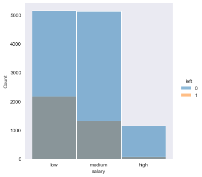

```python
#薪资与离职率
sns.displot(data,x='salary',hue='left');
```

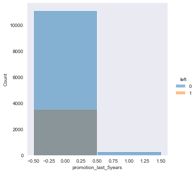

```python
#5年内是否升职与离职率
sns.displot(data,x='promotion_last_5years',hue='left',discrete=True);
#discrete=True,按照值来统计频数
```

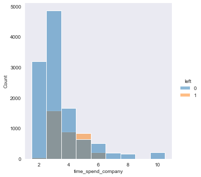

```python
#工作年限分布
sns.displot(data,x='time_spend_company',hue='left',discrete=True);
```

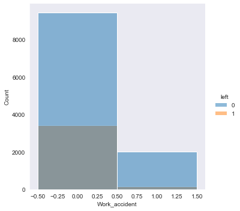

```python
#是否有工作事故与离职率
sns.displot(data,x='Work_accident',hue='left',discrete=True);
```

### 数据预处理：哑变量的处理

```python
#岗位
position_category=pd.get_dummies(data_distinct.sales,prefix='position_category')
position_category.head()
```

|  | position_category_IT | position_category_RandD | position_category_accounting | position_category_hr | position_category_management | position_category_marketing | position_category_product_mng | position_category_sales | position_category_support | position_category_technical |
| --- | --- | --- | --- | --- | --- | --- | --- | --- | --- | --- |
| 0 | 0 | 0 | 0 | 0 | 0 | 0 | 0 | 1 | 0 | 0 |
| 1 | 0 | 0 | 0 | 0 | 0 | 0 | 0 | 1 | 0 | 0 |
| 2 | 0 | 0 | 0 | 0 | 0 | 0 | 0 | 1 | 0 | 0 |
| 3 | 0 | 0 | 0 | 0 | 0 | 0 | 0 | 1 | 0 | 0 |
| 4 | 0 | 0 | 0 | 0 | 0 | 0 | 0 | 1 | 0 | 0 |

```python
#薪资等级
salary_level=pd.get_dummies(data_distinct.salary,prefix='salary_level')
salary_level.head()
```

|  | salary_level_high | salary_level_low | salary_level_medium |
| --- | --- | --- | --- |
| 0 | 0 | 1 | 0 |
| 1 | 0 | 0 | 1 |
| 2 | 0 | 0 | 1 |
| 3 | 0 | 1 | 0 |
| 4 | 0 | 1 | 0 |

```python
#是否出过工作事故、过去5年是否得到提升
Work_accident_dummies=pd.get_dummies(data_distinct.Work_accident,prefix='Work_accident')
promotion_last_5years_dummies=pd.get_dummies(data_distinct.promotion_last_5years,prefix='promotion_last_5years')
```

```python
#将以上4个原来的变量丢弃
data_droped=data_distinct.drop(columns=['sales','salary','Work_accident','promotion_last_5years'])
data_droped.head()
```

|  | satisfaction_level | last_evaluation | number_project | average_montly_hours | time_spend_company | left |
| --- | --- | --- | --- | --- | --- | --- |
| 0 | 0.38 | 0.53 | 2 | 157 | 3 | 1 |
| 1 | 0.80 | 0.86 | 5 | 262 | 6 | 1 |
| 2 | 0.11 | 0.88 | 7 | 272 | 4 | 1 |
| 3 | 0.72 | 0.87 | 5 | 223 | 5 | 1 |
| 4 | 0.37 | 0.52 | 2 | 159 | 3 | 1 |

```python
#加入4个哑变量
data_processed=pd.concat([data_droped,position_category,salary_level,Work_accident_dummies,
                          promotion_last_5years_dummies],axis=1)
data_processed.head().T
```

|  | 0 | 1 | 2 | 3 | 4 |
| --- | --- | --- | --- | --- | --- |
| satisfaction_level | 0.38 | 0.80 | 0.11 | 0.72 | 0.37 |
| last_evaluation | 0.53 | 0.86 | 0.88 | 0.87 | 0.52 |
| number_project | 2.00 | 5.00 | 7.00 | 5.00 | 2.00 |
| average_montly_hours | 157.00 | 262.00 | 272.00 | 223.00 | 159.00 |
| time_spend_company | 3.00 | 6.00 | 4.00 | 5.00 | 3.00 |
| left | 1.00 | 1.00 | 1.00 | 1.00 | 1.00 |
| position_category_IT | 0.00 | 0.00 | 0.00 | 0.00 | 0.00 |
| position_category_RandD | 0.00 | 0.00 | 0.00 | 0.00 | 0.00 |
| position_category_accounting | 0.00 | 0.00 | 0.00 | 0.00 | 0.00 |
| position_category_hr | 0.00 | 0.00 | 0.00 | 0.00 | 0.00 |
| position_category_management | 0.00 | 0.00 | 0.00 | 0.00 | 0.00 |
| position_category_marketing | 0.00 | 0.00 | 0.00 | 0.00 | 0.00 |
| position_category_product_mng | 0.00 | 0.00 | 0.00 | 0.00 | 0.00 |
| position_category_sales | 1.00 | 1.00 | 1.00 | 1.00 | 1.00 |
| position_category_support | 0.00 | 0.00 | 0.00 | 0.00 | 0.00 |
| position_category_technical | 0.00 | 0.00 | 0.00 | 0.00 | 0.00 |
| salary_level_high | 0.00 | 0.00 | 0.00 | 0.00 | 0.00 |
| salary_level_low | 1.00 | 0.00 | 0.00 | 1.00 | 1.00 |
| salary_level_medium | 0.00 | 1.00 | 1.00 | 0.00 | 0.00 |
| Work_accident_0 | 1.00 | 1.00 | 1.00 | 1.00 | 1.00 |
| Work_accident_1 | 0.00 | 0.00 | 0.00 | 0.00 | 0.00 |
| promotion_last_5years_0 | 1.00 | 1.00 | 1.00 | 1.00 | 1.00 |
| promotion_last_5years_1 | 0.00 | 0.00 | 0.00 | 0.00 | 0.00 |

```python
data_processed.info()
```

```
<class 'pandas.core.frame.DataFrame'>
Int64Index: 11991 entries, 0 to 11999
Data columns (total 23 columns):
 #   Column                         Non-Null Count  Dtype
---  ------                         --------------  -----
 0   satisfaction_level             11991 non-null  float64
 1   last_evaluation                11991 non-null  float64
 2   number_project                 11991 non-null  int64
 3   average_montly_hours           11991 non-null  int64
 4   time_spend_company             11991 non-null  int64
 5   left                           11991 non-null  int64
 6   position_category_IT           11991 non-null  uint8
 7   position_category_RandD        11991 non-null  uint8
 8   position_category_accounting   11991 non-null  uint8
 9   position_category_hr           11991 non-null  uint8
 10  position_category_management   11991 non-null  uint8
 11  position_category_marketing    11991 non-null  uint8
 12  position_category_product_mng  11991 non-null  uint8
 13  position_category_sales        11991 non-null  uint8
 14  position_category_support      11991 non-null  uint8
 15  position_category_technical    11991 non-null  uint8
 16  salary_level_high              11991 non-null  uint8
 17  salary_level_low               11991 non-null  uint8
 18  salary_level_medium            11991 non-null  uint8
 19  Work_accident_0                11991 non-null  uint8
 20  Work_accident_1                11991 non-null  uint8
 21  promotion_last_5years_0        11991 non-null  uint8
 22  promotion_last_5years_1        11991 non-null  uint8
dtypes: float64(2), int64(4), uint8(17)
memory usage: 854.8 KB
```

### 定义特征数据和类别标签

```python
X=data_processed.drop(columns=['left'])
y=data_processed['left']
```

## SVM建模

```python
#数据集拆分
from sklearn.model_selection import train_test_split

X_train,X_test,y_train,y_test=train_test_split(X,y,random_state=0)
```

```python
#支持向量机，SVM
from sklearn.svm import SVC

svm_model=SVC()
svm_model.fit(X_train,y_train)

#精度
print("验证集的精度：{:.3f}".format(svm_model.score(X_test,y_test)))
print("训练集的精度：{:.3f}".format(svm_model.score(X_train,y_train)))
```

```
验证集的精度：0.843
训练集的精度：0.831
```

如果数据集的特征的数量级差异较大，那么将对SVM有极大的影响，解决这个问题的一种方法：对数据进行缩。

```python
X[:5].T
```

|  | 0 | 1 | 2 | 3 | 4 |
| --- | --- | --- | --- | --- | --- |
| satisfaction_level | 0.38 | 0.80 | 0.11 | 0.72 | 0.37 |
| last_evaluation | 0.53 | 0.86 | 0.88 | 0.87 | 0.52 |
| number_project | 2.00 | 5.00 | 7.00 | 5.00 | 2.00 |
| average_montly_hours | 157.00 | 262.00 | 272.00 | 223.00 | 159.00 |
| time_spend_company | 3.00 | 6.00 | 4.00 | 5.00 | 3.00 |
| position_category_IT | 0.00 | 0.00 | 0.00 | 0.00 | 0.00 |
| position_category_RandD | 0.00 | 0.00 | 0.00 | 0.00 | 0.00 |
| position_category_accounting | 0.00 | 0.00 | 0.00 | 0.00 | 0.00 |
| position_category_hr | 0.00 | 0.00 | 0.00 | 0.00 | 0.00 |
| position_category_management | 0.00 | 0.00 | 0.00 | 0.00 | 0.00 |
| position_category_marketing | 0.00 | 0.00 | 0.00 | 0.00 | 0.00 |
| position_category_product_mng | 0.00 | 0.00 | 0.00 | 0.00 | 0.00 |
| position_category_sales | 1.00 | 1.00 | 1.00 | 1.00 | 1.00 |
| position_category_support | 0.00 | 0.00 | 0.00 | 0.00 | 0.00 |
| position_category_technical | 0.00 | 0.00 | 0.00 | 0.00 | 0.00 |
| salary_level_high | 0.00 | 0.00 | 0.00 | 0.00 | 0.00 |
| salary_level_low | 1.00 | 0.00 | 0.00 | 1.00 | 1.00 |
| salary_level_medium | 0.00 | 1.00 | 1.00 | 0.00 | 0.00 |
| Work_accident_0 | 1.00 | 1.00 | 1.00 | 1.00 | 1.00 |
| Work_accident_1 | 0.00 | 0.00 | 0.00 | 0.00 | 0.00 |
| promotion_last_5years_0 | 1.00 | 1.00 | 1.00 | 1.00 | 1.00 |
| promotion_last_5years_1 | 0.00 | 0.00 | 0.00 | 0.00 | 0.00 |

## 数据缩放

```python
from sklearn.preprocessing import StandardScaler

Scaler=StandardScaler()
X_Scaled=Scaler.fit_transform(X)
```

```python
X_train,X_test,y_train,y_test=train_test_split(X_Scaled,y,random_state=0)
```

```python
svm_model=SVC()
svm_model.fit(X_train,y_train)

#精度
print("验证集的精度：{:.3f}".format(svm_model.score(X_test,y_test)))
print("训练集的精度：{:.3f}".format(svm_model.score(X_train,y_train)))
```

```
验证集的精度：0.955
训练集的精度：0.958
```

## 调参

```python
## 调参
svm_model=SVC(C=10,gamma=0.01)
svm_model.fit(X_train,y_train)

#精度
print("验证集的精度：{:.3f}".format(svm_model.score(X_test,y_test)))
print("训练集的精度：{:.3f}".format(svm_model.score(X_train,y_train)))
```

```
验证集的精度：0.957
训练集的精度：0.959
```

```python
svm_model.get_params()
```

```
{'C': 10,
 'break_ties': False,
 'cache_size': 200,
 'class_weight': None,
 'coef0': 0.0,
 'decision_function_shape': 'ovr',
 'degree': 3,
 'gamma': 0.01,
 'kernel': 'rbf',
 'max_iter': -1,
 'probability': False,
 'random_state': None,
 'shrinking': True,
 'tol': 0.001,
 'verbose': False}
```

其中，参数C默认等于1，gamma默认是'scale'，取值为1 / (n_features * X.var())；

kernel表示核函数，“ rbf”表示高斯核。

## 调参：网格搜索

### 简单网格搜索

```python
#将标准后的数据集划分为训练集和测试集
X_train,X_test,y_train,y_test=train_test_split(X_Scaled,y,random_state=0)
```

```python
best_score=0 #将最优精度的初始值设置为0

for gamma in [0.001,0.01,0.1,1,10]:
    for C in [0.01,0.1,1,10,100]:
        #对每种参数组合都训练一个SVC
        svm=SVC(gamma=gamma,C=C)
         #训练集用于训练模型
        svm.fit(X_train,y_train)
        #在测试集上评估SVC
        score=svm.score(X_test,y_test) #验证集用于评估所选参数的性能
        #如果得到了更高的分数，则保存该分数和对应的参数
        if score>best_score:
            best_score=score
            best_parameters={'C':C,'gamma':gamma}

#为SVC这个函数设置字典格式的参数
svm=SVC(**best_parameters)
svm.fit(X_train,y_train) #利用训练集训练模型
test_score=svm.score(X_test,y_test) #利用测试集计算精度

print("Best score on validation set:{:.3f}".format(best_score))
print("Best parameters:{}".format(best_parameters))
print("Test set score with best parameters:{:.3f}".format(test_score))
```

```
Best score on validation set:0.972
Best parameters:{'C': 1, 'gamma': 1}
Test set score with best parameters:0.972
```

### 考虑过拟合的网格搜索

```python
#将数据集划分为两部分
X_trainval,X_test,y_trainval,y_test=train_test_split(X_Scaled,y,test_size=0.25,
                                                     random_state=0)

#再将训练集划分为训练集与验证集，验证集用于训练模型，验证集用于评估所选参数
X_train,X_valid,y_train,y_valid=train_test_split(X_trainval,y_trainval,
                                                 random_state=1)
```

```python
best_score=0 #将最优精度的初始值设置为0

for gamma in [0.001,0.01,0.1,1,10]:
    for C in [0.01,0.1,1,10,100]:
        #对每种参数组合都训练一个SVC
        svm=SVC(gamma=gamma,C=C)
        svm.fit(X_train,y_train) #训练集用于训练模型
        #验证集用于评估所选参数的性能
        score=svm.score(X_valid,y_valid)
        #如果得到了更高的分数，则保存该分数和对应的参数
        if score>best_score:
            best_score=score
            best_parameters={'C':C,'gamma':gamma}

#在训练+验证集上重新构建一个模型，并在测试集上进行评估
svm=SVC(**best_parameters)
svm.fit(X_train,y_train) #利用训练集训练模型
test_score=svm.score(X_test,y_test) #利用测试集计算精度

print("Best score on validation set:{:.3f}".format(best_score))
print("Best parameters:{}".format(best_parameters))
print("Test set score with best parameters:{:.3f}".format(test_score))
```

```
Best score on validation set:0.966
Best parameters:{'C': 1, 'gamma': 1}
Test set score with best parameters:0.969
```

### 网格搜索+交叉验证

```python
#将数据集划分为两部分
X_trainval,X_test,y_trainval,y_test=train_test_split(X_Scaled,y,test_size=0.25,
                                                     random_state=0)
```

```python
from sklearn.model_selection import KFold
from sklearn.model_selection import cross_val_score

best_score=0

for gamma in [0.001,0.01,0.1,1,10]:
    for C in [0.01,0.1,1,10,100]:
        #对于每种参数组合都训练一个SVC
        svm=SVC(gamma=gamma,C=C)
        svm.fit(X_trainval,y_trainval)
        #执行交叉验证
        kfolder=KFold(n_splits=5,shuffle=True,random_state=0)
        scores=cross_val_score(svm,X_trainval,y_trainval,cv=kfolder)
        #计算交叉验证平均精度
        score=scores.mean()
        #如果我们得到了更高的分数，则保存分数和对应的参数
        if score>best_score:
            best_score=score
            best_parameters={'C':C,'gamma':gamma}

svm=SVC(**best_parameters)
svm.fit(X_trainval,y_trainval)
test_score=svm.score(X_test,y_test)

print("Best score on validation set:{:.3f}".format(best_score))
print("Best parameters:{}".format(best_parameters))
print("Test set score with best parameters:{:.3f}".format(test_score))
```

```
Best score on validation set:0.965
Best parameters:{'C': 1, 'gamma': 1}
Test set score with best parameters:0.972
```

### 网格搜索：GridSearchCV类

```python
#将数据集划分为两部分
X_train,X_test,y_train,y_test=train_test_split(X_Scaled,y,test_size=0.25,
                                               random_state=0)
```

```python
from sklearn.model_selection import GridSearchCV

#首先将参数以字典的形式定义好
param_grid={'C':[0.001,0.01,0.1,1,10],
           'gamma':[0.01,0.1,1,10,100]}

#然后调用GridSearchCV类，实例化得到grid_search对象
kfolder=KFold(n_splits=5,shuffle=True,random_state=0)
grid_search=GridSearchCV(SVC(),param_grid,cv=kfolder)

#利用grid_search对象拟合训练集
grid_search.fit(X_train,y_train)

#找到的参数保存在best_params_属性中
print("Best parameters:{}".format(grid_search.best_params_))

test_score=grid_search.score(X_test,y_test)
train_score=grid_search.score(X_train,y_train)
print("Test set score with best parameters:{:.3f}".format(test_score))
print("Train set score with best parameters:{:.3f}".format(train_score))
```

```
Best parameters:{'C': 1, 'gamma': 1}
Test set score with best parameters:0.972
Train set score with best parameters:0.985
```

## 带有交叉验证的网格搜索结果可视化

```python
print(grid_search.cv_results_)
```

[output not shown]

```python
import pandas as pd

results=pd.DataFrame(grid_search.cv_results_)
results.head()
```

|  | mean_fit_time | std_fit_time | mean_score_time | std_score_time | param_C | param_gamma | params | split0_test_score | split1_test_score | split2_test_score | split3_test_score | split4_test_score | mean_test_score | std_test_score | rank_test_score |
| --- | --- | --- | --- | --- | --- | --- | --- | --- | --- | --- | --- | --- | --- | --- | --- |
| 0 | 0.844791 | 0.051093 | 0.147698 | 0.008359 | 0.001 | 0.01 | {'C': 0.001, 'gamma': 0.01} | 0.831017 | 0.828794 | 0.836576 | 0.833704 | 0.825362 | 0.831091 | 0.003874 | 15 |
| 1 | 0.848735 | 0.026948 | 0.147139 | 0.007655 | 0.001 | 0.1 | {'C': 0.001, 'gamma': 0.1} | 0.831017 | 0.828794 | 0.836576 | 0.833704 | 0.825362 | 0.831091 | 0.003874 | 15 |
| 2 | 0.779486 | 0.013556 | 0.144868 | 0.003268 | 0.001 | 1 | {'C': 0.001, 'gamma': 1} | 0.831017 | 0.828794 | 0.836576 | 0.833704 | 0.825362 | 0.831091 | 0.003874 | 15 |
| 3 | 0.975777 | 0.026846 | 0.194925 | 0.007299 | 0.001 | 10 | {'C': 0.001, 'gamma': 10} | 0.831017 | 0.828794 | 0.836576 | 0.833704 | 0.825362 | 0.831091 | 0.003874 | 15 |
| 4 | 2.283053 | 0.085195 | 0.511158 | 0.010179 | 0.001 | 100 | {'C': 0.001, 'gamma': 100} | 0.831017 | 0.828794 | 0.836576 | 0.833704 | 0.825362 | 0.831091 | 0.003874 | 15 |

上面采用的是5折交叉验证

```python
#将mean_test_score转换为一个数组
import numpy as np

scores=np.array(results.mean_test_score).reshape(5,5)
scores
```

```
array([[0.8310905 , 0.8310905 , 0.8310905 , 0.8310905 , 0.8310905 ],
       [0.8310905 , 0.8310905 , 0.8310905 , 0.8310905 , 0.8310905 ],
       [0.83175785, 0.91548988, 0.90792864, 0.85755676, 0.8310905 ],
       [0.93761891, 0.95018435, 0.96519553, 0.92105044, 0.85199632],
       [0.95318645, 0.95607713, 0.96230392, 0.92916767, 0.8660075 ]])
```

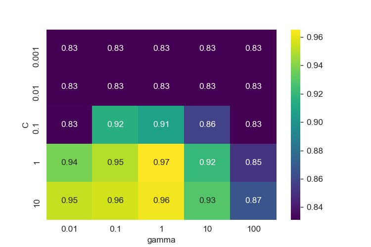

```python
#利用seaborn绘制热力图
%matplotlib notebook
import seaborn as sns
import matplotlib.pyplot as plt

fig,ax=plt.subplots(figsize=(6,4))
sns.heatmap(scores,xticklabels=param_grid['gamma'],yticklabels=param_grid['C'],
            cmap='viridis',annot=True) #annot控制是否在格子中显示数字
ax.set(xlabel='gamma',ylabel='C')
plt.show()
```